```r
# pi0 from the original data ~ 0.26
# pi0 from a combat-cleaned data ~ 0.28
# pi0 from SVA ~ 0.27
```

> *Homework Problem 5:* Apply ComBat and SVA to the Bottomly et al. data. Make a scatter plots of coefficients and a histogram of p-values, comparing results based on ComBat and SVA. Assume that the biological variables in Bottomly et al data is the genetic strains. Make sure that you are pulling out the correct coefficients/pvalues, not any or all of them.

```r
library(sva)
library(broom)
library(ggplot2)
library(tidyr)

edata <- as.matrix(exprs(bottomly.eset))
pheno <- pData(bottomly.eset)

# Filter low expressed genes
edata <- edata[rowMeans(edata) > 10, ]
edata <- log2(edata + 1)

# Remove any rows with NA values
na_rows <- apply(edata, 1, function(x) any(is.na(x)))
edata <- edata[!na_rows, ]

# ComBat correction
mod_for_combat <- model.matrix(~1, data=pheno)
combat_edata <- ComBat(dat=edata, batch=pheno$experiment.number, mod=mod_for_combat, par.prior=TRUE, prior.plots=FALSE)
```

```
## Found3batches
```

```
## Adjusting for0covariate(s) or covariate level(s)
```

```
## Standardizing Data across genes
```

```
## Fitting L/S model and finding priors
```

```
## Finding parametric adjustments
```

```
## Adjusting the Data
```

```r
# model matrices for SVA
mod <- model.matrix(~as.factor(pheno$strain), data=pheno)
mod0 <- model.matrix(~1, data=pheno)

sva_output <- sva(edata, mod, mod0, n.sv=num.sv(edata, mod, method="leek"))
```

```
## Number of significant surrogate variables is:  2
## Iteration (out of 5 ):1  2  3  4  5
```

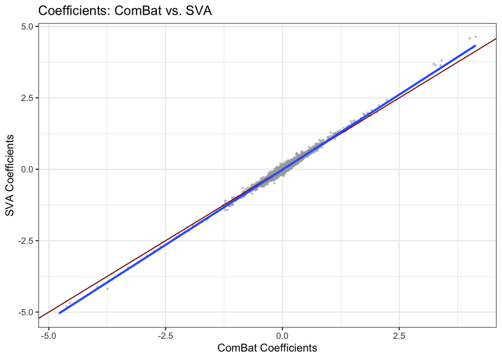

```r
# Linear models
mod_combat <- lm(t(combat_edata) ~ as.factor(pheno$strain))
mod_combat_tidy <- tidy(mod_combat)

mod_sva <- lm(t(edata) ~ as.factor(pheno$strain) + sva_output$sv)
mod_sva_tidy <- tidy(mod_sva)

# coefficients and p-values
combat_coef <- mod_combat_tidy %>%
  filter(term == "as.factor(pheno$strain)DBA/2J") %>%
  pull(estimate)

combat_pvals <- mod_combat_tidy %>%
  filter(term == "as.factor(pheno$strain)DBA/2J") %>%
  pull(p.value)

sva_coef <- mod_sva_tidy %>%
  filter(term == "as.factor(pheno$strain)DBA/2J") %>%
  pull(estimate)

sva_pvals <- mod_sva_tidy %>%
  filter(term == "as.factor(pheno$strain)DBA/2J") %>%
  pull(p.value)

# data frames for plotting
coef_compare <- data.frame(ComBat = combat_coef, SVA = sva_coef)
coef_compare <- na.omit(coef_compare) # na.omit() handle potential NAs in results after model fitting

combat_pvals_df <- data.frame(p.value = combat_pvals)
sva_pvals_df <- data.frame(p.value = sva_pvals)

# Plot coefficients
ggplot(coef_compare, aes(x = ComBat, y = SVA)) +
  geom_point(col = "darkgrey", alpha = 0.5, size = 0.5) +
  geom_abline(intercept = 0, slope = 1, col = "darkred") +
  geom_smooth(method = "lm", se = TRUE) +
  theme_bw() +
  labs(title = "Coefficients: ComBat vs. SVA",
       x = "ComBat Coefficients",
       y = "SVA Coefficients")
```

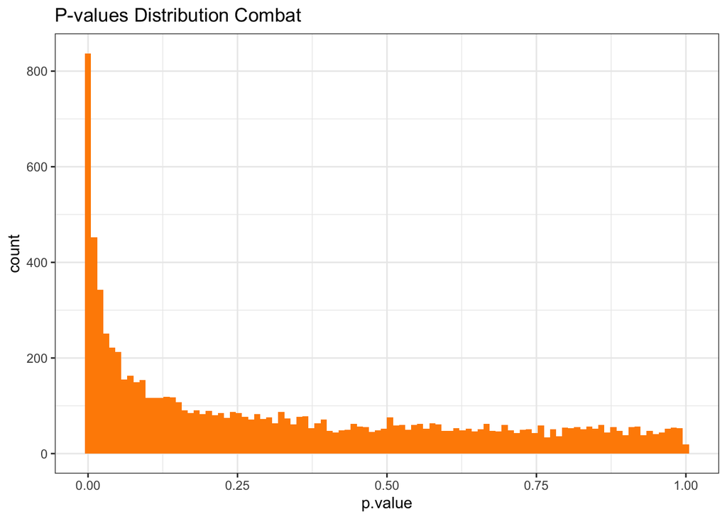

```r
# Plot p-values
ggplot(combat_pvals_df, aes(x = p.value, fill = Method)) +
  geom_histogram(aes(x=p.value), bins = 100, fill="darkorange") +
  theme_bw() +
  labs(title = "P-values Distribution Combat")
```

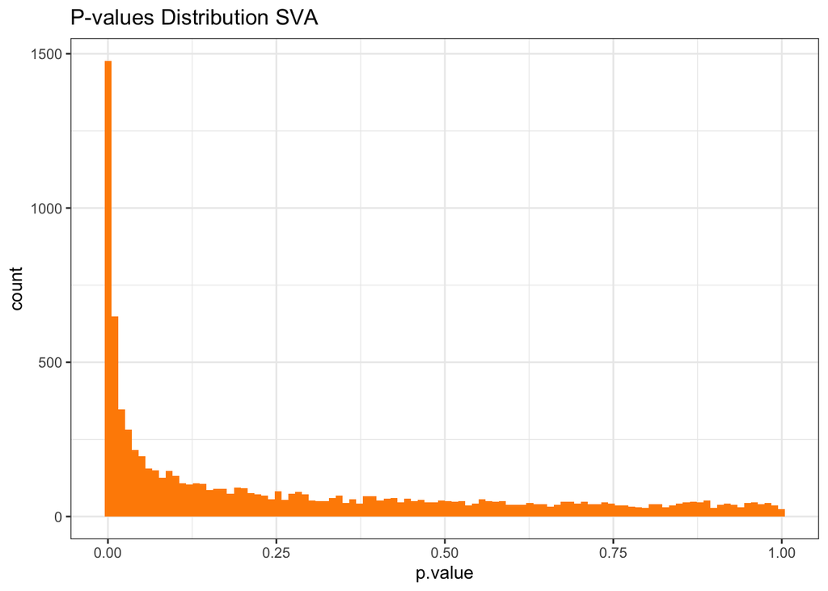

```r
ggplot(sva_pvals_df, aes(x = p.value, fill = Method)) +
  geom_histogram(aes(x=p.value), bins = 100, fill="darkorange")+
  theme_bw() +
  labs(title = "P-values Distribution SVA")
```